# Physician-level Effects Logistic Model

Eunice Yeh

December 8, 2017

# data

load all phys data and clean up real quick

```r
library(tidyverse)
dat <- readRDS("phys_all.rds")
data("state")

EPs <- dat %>% filter(st %in% c(state.abb, "DC") & hosp_afl_1 == '') %>%
  filter(gndr %in% c("F", "M") & !is.na(grd_yr)) %>%
  mutate(yrs_grd = 2016 - as.integer(grd_yr),
         cred = case_when(cred == '' ~ 'NA',
                          TRUE ~ as.character(cred)),
         cred = as.factor(cred),
         ehr = case_when(ehr == 'Y' ~ 1,
                         ehr == '' ~ 0),
         ehr = as.factor(ehr)) %>%
  select(-hosp_afl_1, -hosp_afl_lbn_1, -frst_nm) %>%
  arrange(desc(ehr)) %>%
  distinct(npi, .keep_all = TRUE)

# calculate the number of practices for each physician
SL <- dat %>% group_by(npi) %>% summarise(locations = n_distinct(zip))

EPs <- left_join(EPs, SL, by="npi")

summary(EPs)
```

```
##       cred                 cty         ehr        gndr
##  NA     :250600   NEW YORK   :  5209   0:319592   F:191898
##  MD     : 28396   HOUSTON    :  2714   1: 27069   M:154763
##  DC     : 14284   BROOKLYN   :  2571              U:     0
##  PT     : 10227   LOS ANGELES:  2509
##  OD     : 10048   CHICAGO    :  2343
##  CSW    :  8565   SAN DIEGO  :  2227
##  (Other): 24541   (Other)    :329088
##      grd_yr                                         med_sch
##  Min.   :1939   OTHER                                   :210372
##  1st Qu.:1988   PALMER COLLEGE CHIROPRACTIC - DAVENPORT :  6780
##  Median :1999   LOGAN COLLEGE OF CHIROPRACTIC           :  3455
##  Mean   :1998   PENNSYLVANIA COLLEGE OF OPTOMETRY       :  3400
##  3rd Qu.:2009   SOUTHERN COLLEGE OF OPTOMETRY           :  3273
##  Max.   :2017   ILLINOIS COLLEGE OF OPTOMETRY AT CHICAGO:  3233
##                 (Other)                                 :116148
##       npi                              pri_spec            st
##  Min.   :1.003e+09   PHYSICAL THERAPY      : 52412   CA     : 38142
##  1st Qu.:1.246e+09   CHIROPRACTIC          : 40068   NY     : 28475
##  Median :1.508e+09   CLINICAL SOCIAL WORKER: 37259   TX     : 20644
##  Mean   :1.501e+09   NURSE PRACTITIONER    : 33540   FL     : 20366
##  3rd Qu.:1.750e+09   OPTOMETRY             : 30298   PA     : 14240
##  Max.   :1.993e+09   CLINICAL PSYCHOLOGIST : 24525   IL     : 13663
##                      (Other)               :128559   (Other):211131
##         zip            yrs_grd       locations
##  559050001:  1333   Min.   :-1.0   Min.   :  1.000
##  952103377:  1004   1st Qu.: 7.0   1st Qu.:  1.000
##  948013143:   831   Median :17.0   Median :  1.000
##  207745374:   681   Mean   :18.4   Mean   :  1.289
##  921202507:   593   3rd Qu.:28.0   3rd Qu.:  1.000
##  923356720:   509   Max.   :77.0   Max.   :359.000
##  (Other)  :341710
```

this EPs data now contains only physicians who are not affiliated with any hospital and within the 51 US States where each row is unique to the physician.

# exploratory

```r
library(GGally)
library(reshape2)
library(lme4)
library(lattice)
library(boot)
library(parallel)
library(compiler)
```

1. visualize the relationships between years since graduation and gender.

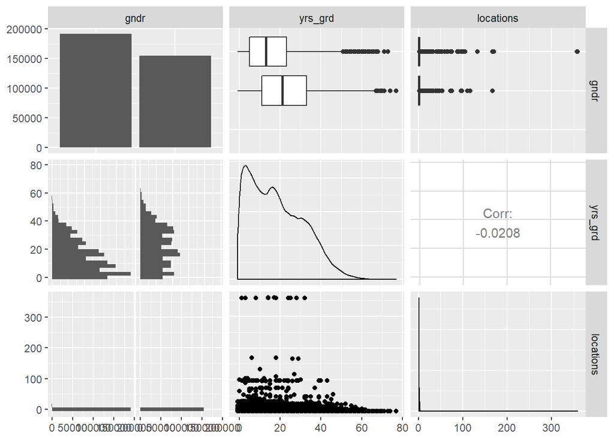

```r
# generic distribution comparisons
EPs %>% ggpairs(columns = c("gndr", "yrs_grd", "locations"))
```

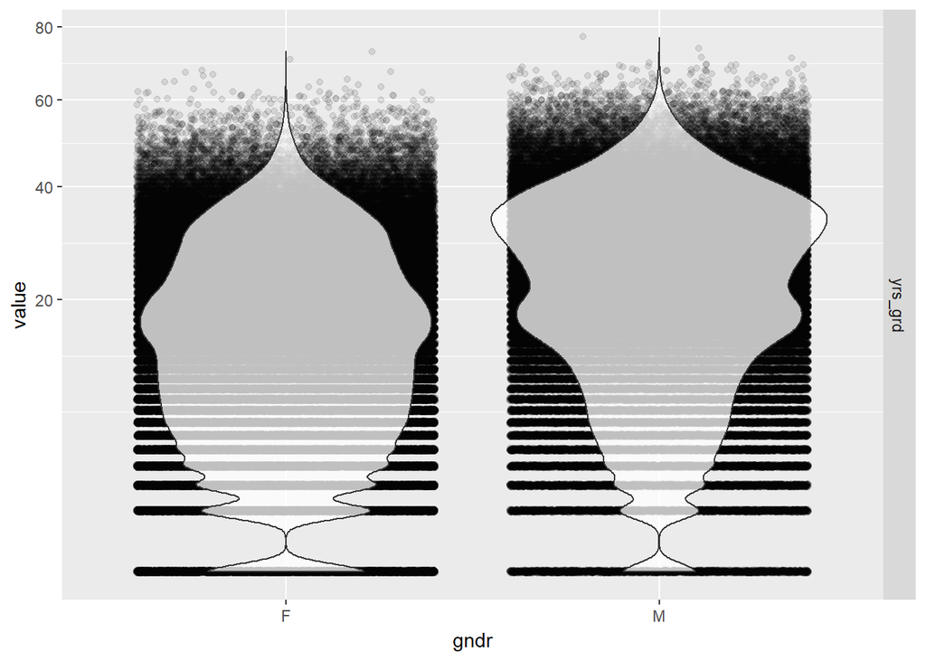

```r
# violin plots with jittering for years since graduation by gender
EPs %>% melt(id.vars="gndr", measure.vars="yrs_grd") %>%
  ggplot(aes(gndr, value)) +
  geom_jitter(alpha = 0.1) +
  geom_violin(alpha = 0.75) +
  facet_grid(variable ~ .) +
  scale_y_sqrt()
```

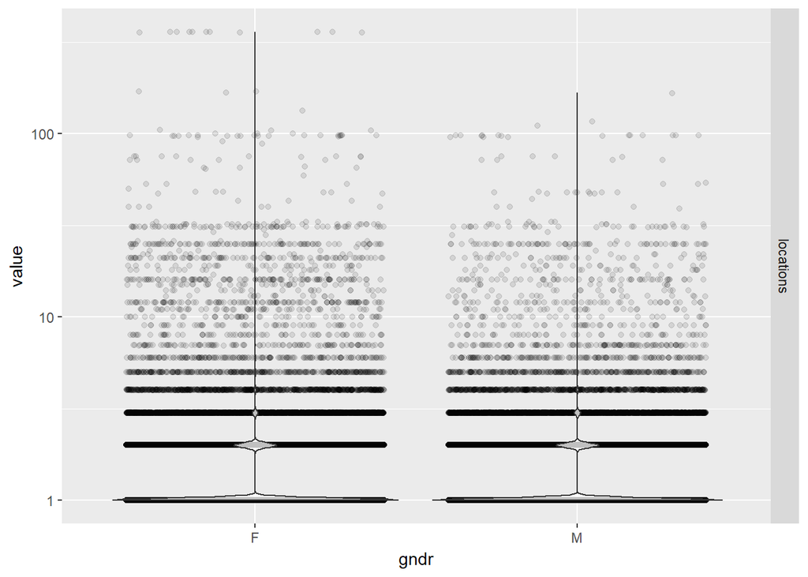

```r
# violin plots with jittering for locations by gender
EPs %>% melt(id.vars="gndr", measure.vars="locations") %>%
  ggplot(aes(gndr, value)) +
  geom_jitter(alpha = 0.1) +
  geom_violin(alpha = 0.75) +
  facet_grid(variable ~ .) +
  scale_y_log10()
```

in the grand scheme of things, i think it’s safe to say that gender is pretty independent of years since graduation. so we should be able to add them into the model together without them influencing each other’s effects. Also, the distribution of years since graduation is pretty skewed, we used a square root scale so that’s why the kernel density curves in the violin plots look more symmetric than the histograms from `ggpairs`. The actual raw values of the years since graduation were not square-root transformed though so we can see and intepret the actual years rather than the square root of the years.

update: i later added in the number of locations just because it’s another continuous variable we can look at, but really most physicians in the data have only one practice location and then there’s a jump to a few physicians who have >300 unique zip codes of all their practices. this distribution is seen equally across genders and years since graduation, so clearly very independent of the two other variables - so it can be safely added to the model. but i’m just afraid that this information is already not so valid? it’s really more of a categorical variable.

2. credentials is one of the categorical variables with the least number of levels, let’s see if we can add this into the model too. first check the relationship between years since graduation and credentials.

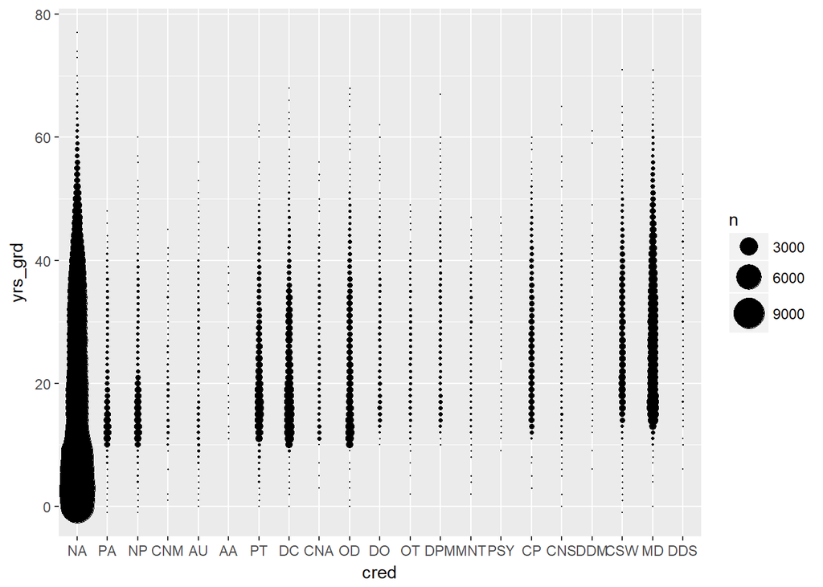

```r
EPs %>% mutate(cred = reorder(cred, yrs_grd)) %>%
  ggplot(aes(cred, yrs_grd)) +
  stat_sum(aes(size = ..n.., group = 1)) +
  scale_size_area(max_size = 10)
```

the distribution of years since graduation looks pretty consistent across different levels of credentials, except for AA due to small sample size and NA due to disproportionally large sample size. “NA” is unknown credential and unfortunately the majority of our physicians fell in that category (perhaps many people skip the credentials field because it’s not a required field or unnecessary if the dataset is already going to be mostly doctors?) anyway, this tells us that we probably shouldn’t use credentials as a variable since it’s mostly missing (~75% NAs).

3. now look at the relationship of each of these effects of interest with the outcome of EHR use

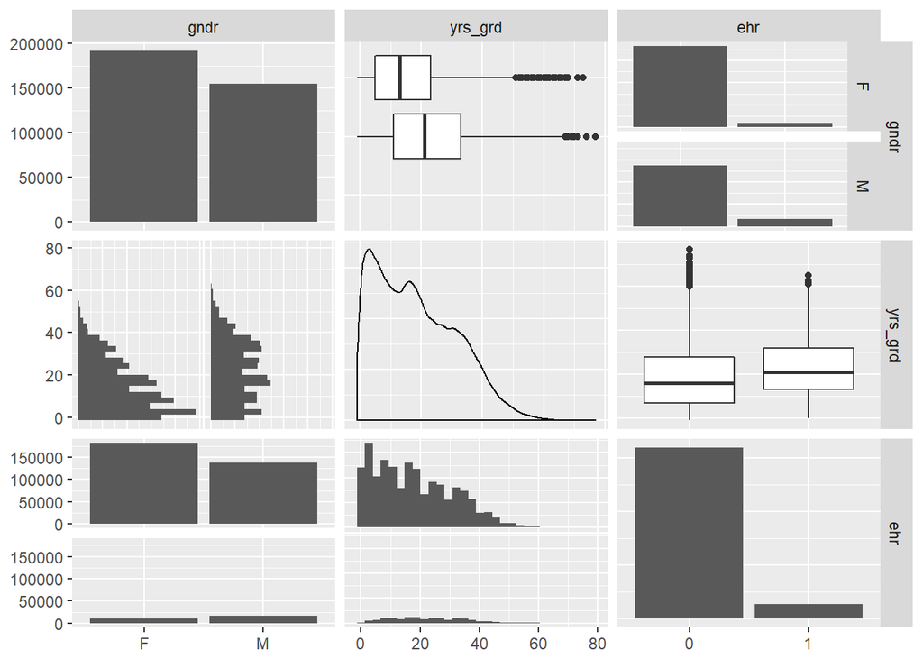

```r
# gender and years since graduation and EHR use
EPs %>% ggpairs(columns = c("gndr", "yrs_grd", "ehr"))
```

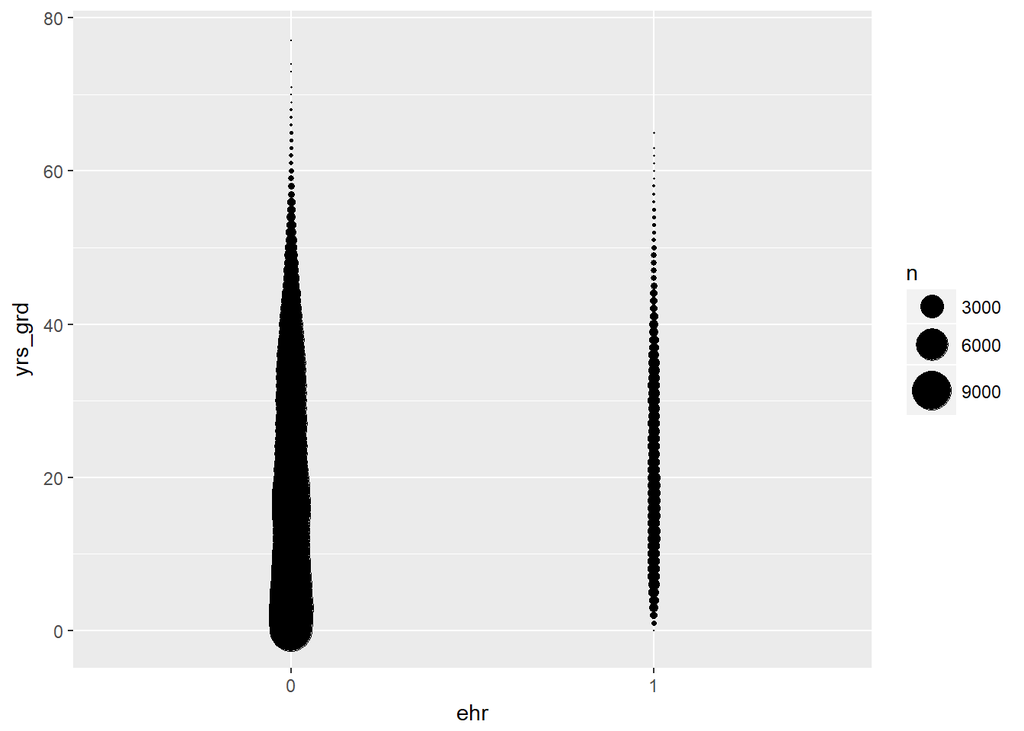

```r
# years since graduation by EHR use
EPs %>% ggplot(aes(ehr, yrs_grd)) +
  stat_sum(aes(size = ..n.., group = 1)) +
  scale_size_area(max_size = 10)
```

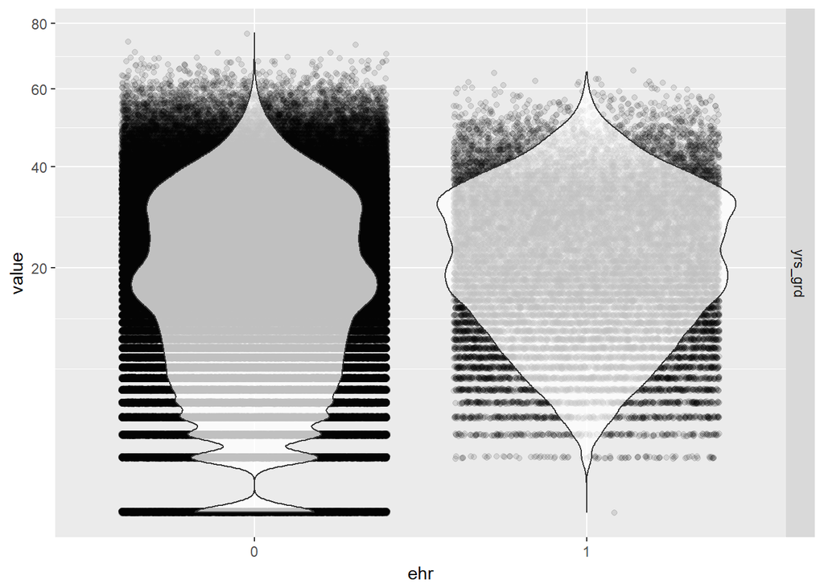

```r
# years since graduation by EHR use
EPs %>% melt(id.vars="ehr", measure.vars="yrs_grd") %>%
  ggplot(aes(ehr, value)) +
  geom_jitter(alpha = 0.1) +
  geom_violin(alpha = 0.75) +
  facet_grid(variable ~ .) +
  scale_y_sqrt()
```

a general observation is that there are proportionally more physicians in our data who have not used EHR. so we already have an imbalance in sample size between the two groups. but overall, our sample size is still large enough.

4. although we can’t add the other categorical variables with too many levels to the model, we will still explore the high-level relationship between these categorical variables with ehr use. here’s a correlation matrix of numeric levels of med school and primary specialty with ehr use.

```
## Computing correlation using pearson-method with listwise-deletion...
```

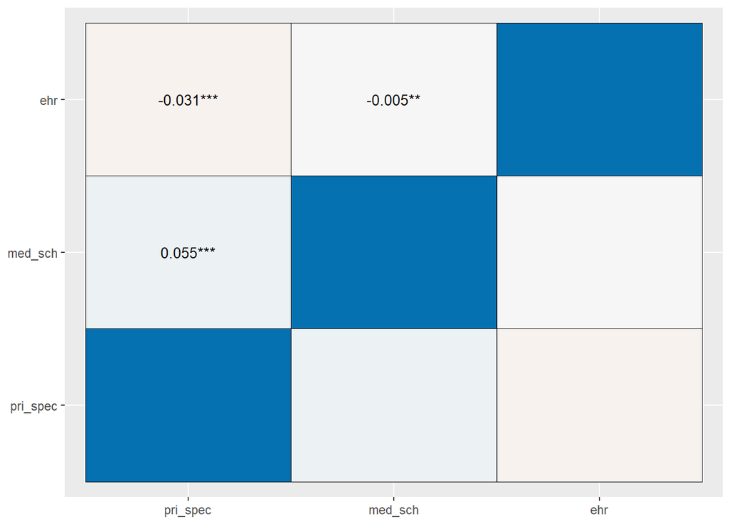

```r
library(sjPlot)
EPs %>% select(ehr, med_sch, pri_spec) %>%
  mutate(ehr = as.integer(ehr), med_sch = as.integer(med_sch), pri_spec = as.integer(pri_spec)) %>%
  sjp.corr()
```

the correlation coefficients are not very high…maybe they’re not interesting after all?

# logistic regression model: effects of physicial-level demographics on the use of EHR

```r
# fit the model
model <- glm(ehr ~ gndr + yrs_grd + locations, data = EPs, family = binomial)
summary(model)
```

```
##
## Call:
## glm(formula = ehr ~ gndr + yrs_grd + locations, family = binomial,
##     data = EPs)
##
## Deviance Residuals:
##     Min       1Q   Median       3Q      Max
## -0.7356  -0.4559  -0.3525  -0.3010   2.5415
##
## Coefficients:
##               Estimate Std. Error  z value Pr(>|z|)
## (Intercept) -3.1939754  0.0135702 -235.366   <2e-16 ***
## gndrM        0.7063633  0.0136254   51.842   <2e-16 ***
## yrs_grd      0.0170934  0.0004781   35.754   <2e-16 ***
## locations    0.0023898  0.0020559    1.162    0.245
## ---
## Signif. codes:  0 '***' 0.001 '**' 0.01 '*' 0.05 '.' 0.1 ' ' 1
##
## (Dispersion parameter for binomial family taken to be 1)
##
##     Null deviance: 190017  on 346660  degrees of freedom
## Residual deviance: 184554  on 346657  degrees of freedom
## AIC: 184562
##
## Number of Fisher Scoring iterations: 5
```

```r
# confidence intervals with log-likelihood
confint(model)
```

```
##                    2.5 %       97.5 %
## (Intercept) -3.220607670 -3.167406404
## gndrM        0.679678956  0.733091756
## yrs_grd      0.016156186  0.018030298
## locations   -0.002208467  0.005994101
```

table of 95% confidence intervals

```r
# CIs using standard errors
confint.default(model)
```

```
##                    2.5 %       97.5 %
## (Intercept) -3.220572634 -3.167378237
## gndrM        0.679658005  0.733068645
## yrs_grd      0.016156392  0.018030462
## locations   -0.001639739  0.006419436
```

table of odds ratios

```r
exp(coef(model))
```

```
## (Intercept)       gndrM     yrs_grd   locations
##  0.04100852  2.02660773  1.01724036  1.00239271
```

table of odds ratios with 95% CI

```r
exp(cbind(OR = coef(model), confint(model)))
```

```
##                     OR      2.5 %     97.5 %
## (Intercept) 0.04100852 0.03993079 0.04211268
## gndrM       2.02660773 1.97324413 2.08150618
## yrs_grd     1.01724036 1.01628740 1.01819383
## locations   1.00239271 0.99779397 1.00601210
```

should we do a predicted probability of ehr use at each level of gender, years since graduation, and location?